# Machine Learning in the Tidyverse

Ryan Hawkins

November 10, 2018

# Part 1

## Nesting your data

```r
# Omit na rows
gapminder <- as.tibble(gapminder)
gapminder <- gapminder %>% drop_na()

#Eplore the gapminder dataset
summary(gapminder)
```

```
##        country          year      infant_mortality life_expectancy
##  Algeria   :  52   Min.   :1960   Min.   :  1.80   Min.   :13.20
##  Argentina :  52   1st Qu.:1978   1st Qu.: 16.00   1st Qu.:56.90
##  Australia :  52   Median :1991   Median : 41.70   Median :67.58
##  Austria   :  52   Mean   :1989   Mean   : 54.88   Mean   :64.83
##  Bangladesh:  52   3rd Qu.:2001   3rd Qu.: 85.40   3rd Qu.:73.20
##  Belgium   :  52   Max.   :2011   Max.   :237.20   Max.   :82.90
##  (Other)   :6827
##    fertility       population             gdp               continent
##  Min.   :1.130   Min.   :4.154e+04   Min.   :4.040e+07   Africa  :2203
##  1st Qu.:2.160   1st Qu.:2.115e+06   1st Qu.:1.974e+09   Americas:1546
##  Median :3.720   Median :6.531e+06   Median :8.249e+09   Asia    :1598
##  Mean   :4.045   Mean   :3.236e+07   Mean   :1.556e+11   Europe  :1418
##  3rd Qu.:5.900   3rd Qu.:2.003e+07   3rd Qu.:5.843e+10   Oceania : 374
##  Max.   :8.670   Max.   :1.348e+09   Max.   :1.174e+13
##
##              region
##  Western Africa : 749
##  Eastern Africa : 637
##  South America  : 601
##  Western Asia   : 560
##  Caribbean      : 432
##  Central America: 409
##  (Other)        :3751
```

```r
str(gapminder)
```

```
## Classes 'tbl_df', 'tbl' and 'data.frame':    7139 obs. of  9 variables:
##  $ country         : Factor w/ 185 levels "Albania","Algeria",..: 2 5 8 9 11 13 14 16 18 20 ...
##  $ year            : int  1960 1960 1960 1960 1960 1960 1960 1960 1960 1960 ...
##  $ infant_mortality: num  148.2 59.9 20.3 37.3 51 ...
##  $ life_expectancy : num  47.5 65.4 70.9 68.8 62 ...
##  $ fertility       : num  7.65 3.11 3.45 2.7 4.5 6.73 4.33 2.6 6.28 6.7 ...
##  $ population      : num  11124892 20619075 10292328 7065525 109526 ...
##  $ gdp             : num  1.38e+10 1.08e+11 9.67e+10 5.24e+10 1.31e+09 ...
##  $ continent       : Factor w/ 5 levels "Africa","Americas",..: 1 2 5 4 2 3 2 4 1 2 ...
##  $ region          : Factor w/ 22 levels "Australia and New Zealand",..: 11 15 1 22 2 18 2 22 20 15 ...
```

```r
# Prepare the nested dataframe gap_nested
library(tidyverse)
gap_nested <- gapminder %>%
  group_by(country) %>%
  nest()

# Explore gap_nested
head(gap_nested)
```

```
## # A tibble: 6 x 2
##   country    data
##   <fct>      <list>
## 1 Algeria    <tibble [52 x 8]>
## 2 Argentina  <tibble [52 x 8]>
## 3 Australia  <tibble [52 x 8]>
## 4 Austria    <tibble [52 x 8]>
## 5 Bahamas    <tibble [45 x 8]>
## 6 Bangladesh <tibble [52 x 8]>
```

## Unnesting your data

A nested dataframe is simply a way to shape your data. Essentially taking the group_by() windows and packaging them in corresponding rows.

In the same way you can use the nest() function to break your data into nested chunks, you can use the unnest() function to expand the dataframes that are nested in these chunks.

```r
# Create the unnested dataframe called gap_unnnested
gap_unnested <- gap_nested %>%
  unnest()

# Confirm that your data was not modified
identical(gap_unnested, gapminder)
```

```
## [1] FALSE
```

## Explore a nested cell

In the first exercise, you successfully created a nested dataframe gap_nested. The data column contains tibbles for each country. Here you will explore one of these nested chunks.

```r
# Extract the data of Algeria
algeria_df <- gap_nested$data[[1]]

# Calculate the minimum of the population vector
min(algeria_df$population)
```

```
## [1] 11124892
```

```r
# Calculate the maximum of the population vector
max(algeria_df$population)
```

```
## [1] 36717132
```

```r
# Calculate the mean of the population vector
mean(algeria_df$population)
```

```
## [1] 23129438
```

## Mapping your data

In combination with mutate(), you can use map() to append the results of your calculation to a dataframe. Since the map() function always returns a vector of lists you must use unnest() to extract this information into a numeric vector.

```r
# Calculate the mean population for each country
pop_nested <- gap_nested %>%
  mutate(mean_pop = map(gap_nested$data, ~mean(.x$population)))

# Take a look at pop_nested
head(pop_nested)
```

```
## # A tibble: 6 x 3
##   country    data              mean_pop
##   <fct>      <list>            <list>
## 1 Algeria    <tibble [52 x 8]> <dbl [1]>
## 2 Argentina  <tibble [52 x 8]> <dbl [1]>
## 3 Australia  <tibble [52 x 8]> <dbl [1]>
## 4 Austria    <tibble [52 x 8]> <dbl [1]>
## 5 Bahamas    <tibble [45 x 8]> <dbl [1]>
## 6 Bangladesh <tibble [52 x 8]> <dbl [1]>
```

```r
# Extract the mean_pop value by using unnest
pop_mean <- pop_nested %>%
  unnest(mean_pop)

# Take a look at pop_mean
head(pop_mean)
```

```
## # A tibble: 6 x 3
##   country    data               mean_pop
##   <fct>      <list>                <dbl>
## 1 Algeria    <tibble [52 x 8]> 23129438.
## 2 Argentina  <tibble [52 x 8]> 30783053.
## 3 Australia  <tibble [52 x 8]> 16074837.
## 4 Austria    <tibble [52 x 8]>  7746272.
## 5 Bahamas    <tibble [45 x 8]>   252813.
## 6 Bangladesh <tibble [52 x 8]> 97649407.
```

## Expecting mapped output

When you know that the output of your mapped function is an expected type (here it is a numeric vector) you can leverage the map_*() family of functions to explicitly try to return that object type instead of a list.

```r
# Calculate mean population and store result as a double
pop_mean <- gap_nested %>%
  mutate(mean_pop = map_dbl(gap_nested$data, ~mean(.x$population)))

# Take a look at pop_mean
head(pop_mean)
```

```
## # A tibble: 6 x 3
##   country    data               mean_pop
##   <fct>      <list>                <dbl>
## 1 Algeria    <tibble [52 x 8]> 23129438.
## 2 Argentina  <tibble [52 x 8]> 30783053.
## 3 Australia  <tibble [52 x 8]> 16074837.
## 4 Austria    <tibble [52 x 8]>  7746272.
## 5 Bahamas    <tibble [45 x 8]>   252813.
## 6 Bangladesh <tibble [52 x 8]> 97649407.
```

## Mapping many models

The gap_nested dataframe available in your workspace contains the gapminder dataset nested by country.

You will use this data to build a linear model for each country to predict life expectancy using the year feature.

```r
# Build a linear model for each country
gap_models <- gap_nested %>%
    mutate(model = map(data, ~lm(formula = life_expectancy~year, data = .x)))

# Extract the model for Algeria
algeria_model <- gap_models$model[[1]]

# View the summary for the Algeria model
summary(algeria_model)
```

```
##
## Call:
## lm(formula = life_expectancy ~ year, data = .x)
##
## Residuals:
##    Min     1Q Median     3Q    Max
## -4.044 -1.577 -0.543  1.700  3.843
##
## Coefficients:
##               Estimate Std. Error t value Pr(>|t|)
## (Intercept) -1.197e+03  3.994e+01  -29.96   <2e-16 ***
## year         6.349e-01  2.011e-02   31.56   <2e-16 ***
## ---
## Signif. codes:  0 '***' 0.001 '**' 0.01 '*' 0.05 '.' 0.1 ' ' 1
##
## Residual standard error: 2.177 on 50 degrees of freedom
## Multiple R-squared:  0.9522, Adjusted R-squared:  0.9513
## F-statistic: 996.2 on 1 and 50 DF,  p-value: < 2.2e-16
```

## Extracting model statistics tidily

In this exercise, you will use the tidy() and glance() functions to extract information from algeria_model in a tidy manner.

For a linear model, tidy() extracts the model coefficients while glance() returns the model statistics such as the R2.

```r
# Extract the coefficients of the algeria_model as a dataframe
tidy(algeria_model)
```

```
## # A tibble: 2 x 5
##   term         estimate std.error statistic  p.value
##   <chr>           <dbl>     <dbl>     <dbl>    <dbl>
## 1 (Intercept) -1197.      39.9        -30.0 1.32e-33
## 2 year            0.635    0.0201      31.6 1.11e-34
```

```r
# Extract the statistics of the algeria_model as a dataframe
glance(algeria_model)
```

```
## # A tibble: 1 x 11
##   r.squared adj.r.squared sigma statistic  p.value    df logLik   AIC   BIC
## *     <dbl>         <dbl> <dbl>     <dbl>    <dbl> <int>  <dbl> <dbl> <dbl>
## 1     0.952         0.951  2.18      996. 1.11e-34     2  -113.  232.  238.
## # ... with 2 more variables: deviance <dbl>, df.residual <int>
```

## Augmenting your data

Here you will leverage this to compare the predicted values of life_expectancy with the original ones based on the year feature.

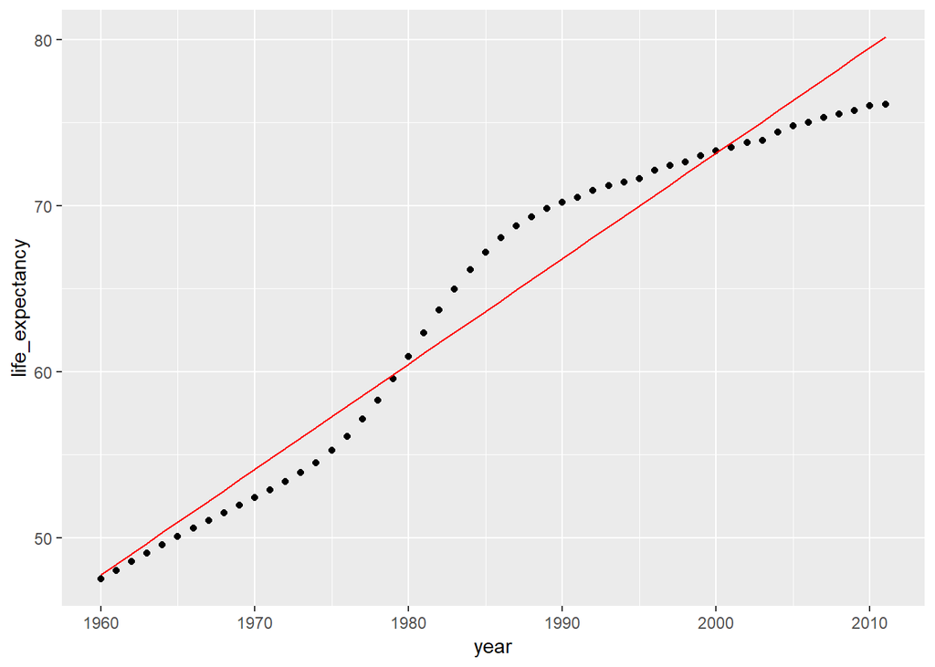

```r
# Build the augmented dataframe
algeria_fitted <- augment(algeria_model)

# Compare the predicted values with the actual values of life expectancy
algeria_fitted %>%
  ggplot(aes(x = year)) +
  geom_point(aes(y = life_expectancy)) +
  geom_line(aes(y = .fitted), color = "red")
```